# Vehicle Classification

### Data Description:

The data contains features extracted from the silhouette of vehicles in different angles. Four "Corgie" model vehicles were used for the experiment: a double decker bus,Cheverolet van, Saab 9000 and an Opel Manta 400 cars.  
This particular combination of vehicles was chosen with the expectation that the bus, van and either one of the cars would be readily distinguishable, but it would be more difficult to distinguish between the cars.

### Domain:

Object recognition

### Context:

The purpose is to classify a given silhouette as one of three types of vehicle, using a set of features extracted from the silhouette. The vehicle may be viewed from one of many different angles.

### Objective:

Apply dimensionality reduction technique – PCA and train a model using principle components instead of training the model using just the raw data.

## Steps:

## 1. Data pre-processing – Perform all the necessary preprocessing

### a. Import Libraries

```python
# importing the necessary libraries.

import numpy as np
import pandas as pd
from matplotlib import pyplot as plt
import seaborn as sns
%matplotlib inline
import warnings
warnings.filterwarnings('ignore')
```

### b. Import and Review the data

```python
# import the data

vData = pd.read_csv("vehicle.csv")

vData.shape
```

```
(846, 19)
```

```python
vData.head(10)
```

|  | compactness | circularity | distance_circularity | radius_ratio | pr.axis_aspect_ratio | max.length_aspect_ratio | scatter_ratio | elongatedness | pr.axis_rectangularity | max.length_rectangularity | scaled_variance | scaled_variance.1 | scaled_radius_of_gyration | scaled_radius_of_gyration.1 | skewness_about | skewness_about.1 | skewness_about.2 | hollows_ratio | class |
| --- | --- | --- | --- | --- | --- | --- | --- | --- | --- | --- | --- | --- | --- | --- | --- | --- | --- | --- | --- |
| 0 | 95 | 48.0 | 83.0 | 178.0 | 72.0 | 10 | 162.0 | 42.0 | 20.0 | 159 | 176.0 | 379.0 | 184.0 | 70.0 | 6.0 | 16.0 | 187.0 | 197 | van |
| 1 | 91 | 41.0 | 84.0 | 141.0 | 57.0 | 9 | 149.0 | 45.0 | 19.0 | 143 | 170.0 | 330.0 | 158.0 | 72.0 | 9.0 | 14.0 | 189.0 | 199 | van |
| 2 | 104 | 50.0 | 106.0 | 209.0 | 66.0 | 10 | 207.0 | 32.0 | 23.0 | 158 | 223.0 | 635.0 | 220.0 | 73.0 | 14.0 | 9.0 | 188.0 | 196 | car |
| 3 | 93 | 41.0 | 82.0 | 159.0 | 63.0 | 9 | 144.0 | 46.0 | 19.0 | 143 | 160.0 | 309.0 | 127.0 | 63.0 | 6.0 | 10.0 | 199.0 | 207 | van |
| 4 | 85 | 44.0 | 70.0 | 205.0 | 103.0 | 52 | 149.0 | 45.0 | 19.0 | 144 | 241.0 | 325.0 | 188.0 | 127.0 | 9.0 | 11.0 | 180.0 | 183 | bus |
| 5 | 107 | NaN | 106.0 | 172.0 | 50.0 | 6 | 255.0 | 26.0 | 28.0 | 169 | 280.0 | 957.0 | 264.0 | 85.0 | 5.0 | 9.0 | 181.0 | 183 | bus |
| 6 | 97 | 43.0 | 73.0 | 173.0 | 65.0 | 6 | 153.0 | 42.0 | 19.0 | 143 | 176.0 | 361.0 | 172.0 | 66.0 | 13.0 | 1.0 | 200.0 | 204 | bus |
| 7 | 90 | 43.0 | 66.0 | 157.0 | 65.0 | 9 | 137.0 | 48.0 | 18.0 | 146 | 162.0 | 281.0 | 164.0 | 67.0 | 3.0 | 3.0 | 193.0 | 202 | van |
| 8 | 86 | 34.0 | 62.0 | 140.0 | 61.0 | 7 | 122.0 | 54.0 | 17.0 | 127 | 141.0 | 223.0 | 112.0 | 64.0 | 2.0 | 14.0 | 200.0 | 208 | van |
| 9 | 93 | 44.0 | 98.0 | NaN | 62.0 | 11 | 183.0 | 36.0 | 22.0 | 146 | 202.0 | 505.0 | 152.0 | 64.0 | 4.0 | 14.0 | 195.0 | 204 | car |

```python
vData.info()
```

```
<class 'pandas.core.frame.DataFrame'>
RangeIndex: 846 entries, 0 to 845
Data columns (total 19 columns):
compactness                    846 non-null int64
circularity                    841 non-null float64
distance_circularity           842 non-null float64
radius_ratio                   840 non-null float64
pr.axis_aspect_ratio           844 non-null float64
max.length_aspect_ratio        846 non-null int64
scatter_ratio                  845 non-null float64
elongatedness                  845 non-null float64
pr.axis_rectangularity         843 non-null float64
max.length_rectangularity      846 non-null int64
scaled_variance                843 non-null float64
scaled_variance.1              844 non-null float64
scaled_radius_of_gyration      844 non-null float64
scaled_radius_of_gyration.1    842 non-null float64
skewness_about                 840 non-null float64
skewness_about.1               845 non-null float64
skewness_about.2               845 non-null float64
hollows_ratio                  846 non-null int64
class                          846 non-null object
dtypes: float64(14), int64(4), object(1)
memory usage: 125.7+ KB
```

```python
vData.describe().T
```

|  | count | mean | std | min | 25% | 50% | 75% | max |
| --- | --- | --- | --- | --- | --- | --- | --- | --- |
| compactness | 846.0 | 93.678487 | 8.234474 | 73.0 | 87.00 | 93.0 | 100.0 | 119.0 |
| circularity | 841.0 | 44.828775 | 6.152172 | 33.0 | 40.00 | 44.0 | 49.0 | 59.0 |
| distance_circularity | 842.0 | 82.110451 | 15.778292 | 40.0 | 70.00 | 80.0 | 98.0 | 112.0 |
| radius_ratio | 840.0 | 168.888095 | 33.520198 | 104.0 | 141.00 | 167.0 | 195.0 | 333.0 |
| pr.axis_aspect_ratio | 844.0 | 61.678910 | 7.891463 | 47.0 | 57.00 | 61.0 | 65.0 | 138.0 |
| max.length_aspect_ratio | 846.0 | 8.567376 | 4.601217 | 2.0 | 7.00 | 8.0 | 10.0 | 55.0 |
| scatter_ratio | 845.0 | 168.901775 | 33.214848 | 112.0 | 147.00 | 157.0 | 198.0 | 265.0 |
| elongatedness | 845.0 | 40.933728 | 7.816186 | 26.0 | 33.00 | 43.0 | 46.0 | 61.0 |
| pr.axis_rectangularity | 843.0 | 20.582444 | 2.592933 | 17.0 | 19.00 | 20.0 | 23.0 | 29.0 |
| max.length_rectangularity | 846.0 | 147.998818 | 14.515652 | 118.0 | 137.00 | 146.0 | 159.0 | 188.0 |
| scaled_variance | 843.0 | 188.631079 | 31.411004 | 130.0 | 167.00 | 179.0 | 217.0 | 320.0 |
| scaled_variance.1 | 844.0 | 439.494076 | 176.666903 | 184.0 | 318.00 | 363.5 | 587.0 | 1018.0 |
| scaled_radius_of_gyration | 844.0 | 174.709716 | 32.584808 | 109.0 | 149.00 | 173.5 | 198.0 | 268.0 |
| scaled_radius_of_gyration.1 | 842.0 | 72.447743 | 7.486190 | 59.0 | 67.00 | 71.5 | 75.0 | 135.0 |
| skewness_about | 840.0 | 6.364286 | 4.920649 | 0.0 | 2.00 | 6.0 | 9.0 | 22.0 |
| skewness_about.1 | 845.0 | 12.602367 | 8.936081 | 0.0 | 5.00 | 11.0 | 19.0 | 41.0 |
| skewness_about.2 | 845.0 | 188.919527 | 6.155809 | 176.0 | 184.00 | 188.0 | 193.0 | 206.0 |
| hollows_ratio | 846.0 | 195.632388 | 7.438797 | 181.0 | 190.25 | 197.0 | 201.0 | 211.0 |

### Deductions:

1. The data has 19 columns. 18 independant attributes, and a target attribute "class"
2. All independant attributes are numeric.
3. There are 846 data points in total.
4. Notice many attributes, have less than 846 datapoints, meaning the data has missing values.
5. Notice, for most of the attributes mean appox equals the 50 percentile, indicating symmetrical distrubution.
6. Only radius_ratio, pr.axis_aspect_ratio, max.length_aspect_ratio, scatter_ratio, scaled_variance, scaled_variance.1, skewness_about, skewness_about.1 appear to be skewed to the right.

### c. Dealing with missing values

```python
#vData.head(10)

print("Missing values if any (True/False)? :", vData.isnull().values.any())
vData.isna().apply(pd.value_counts).T
```

```
Missing values if any (True/False)? : True
```

|  | False | True |
| --- | --- | --- |
| compactness | 846.0 | NaN |
| circularity | 841.0 | 5.0 |
| distance_circularity | 842.0 | 4.0 |
| radius_ratio | 840.0 | 6.0 |
| pr.axis_aspect_ratio | 844.0 | 2.0 |
| max.length_aspect_ratio | 846.0 | NaN |
| scatter_ratio | 845.0 | 1.0 |
| elongatedness | 845.0 | 1.0 |
| pr.axis_rectangularity | 843.0 | 3.0 |
| max.length_rectangularity | 846.0 | NaN |
| scaled_variance | 843.0 | 3.0 |
| scaled_variance.1 | 844.0 | 2.0 |
| scaled_radius_of_gyration | 844.0 | 2.0 |
| scaled_radius_of_gyration.1 | 842.0 | 4.0 |
| skewness_about | 840.0 | 6.0 |
| skewness_about.1 | 845.0 | 1.0 |
| skewness_about.2 | 845.0 | 1.0 |
| hollows_ratio | 846.0 | NaN |
| class | 846.0 | NaN |

#### As noticed above, since most of the attributes are symmetrically skewed and the no.of missing values are very low, we will replace them with mean.

```python
#print("Mean values :\n", vData.mean())

# creating a meanfiller to replace all column missing values with mean
meanFiller = lambda x: x.fillna(x.mean())

vData_num = vData.loc[:,vData.columns != 'class']
vData_cat = vData.loc[:,vData.columns == 'class']
vData_num = vData_num.apply(meanFiller,axis=0)

vData = pd.concat([vData_num, vData_cat], axis = 1)
vData.info()
```

```
<class 'pandas.core.frame.DataFrame'>
RangeIndex: 846 entries, 0 to 845
Data columns (total 19 columns):
compactness                    846 non-null int64
circularity                    846 non-null float64
distance_circularity           846 non-null float64
radius_ratio                   846 non-null float64
pr.axis_aspect_ratio           846 non-null float64
max.length_aspect_ratio        846 non-null int64
scatter_ratio                  846 non-null float64
elongatedness                  846 non-null float64
pr.axis_rectangularity         846 non-null float64
max.length_rectangularity      846 non-null int64
scaled_variance                846 non-null float64
scaled_variance.1              846 non-null float64
scaled_radius_of_gyration      846 non-null float64
scaled_radius_of_gyration.1    846 non-null float64
skewness_about                 846 non-null float64
skewness_about.1               846 non-null float64
skewness_about.2               846 non-null float64
hollows_ratio                  846 non-null int64
class                          846 non-null object
dtypes: float64(14), int64(4), object(1)
memory usage: 125.7+ KB
```

#### Notice, now all attributes have 846 data points. We have replaced missing values with the mean value of each attribute.

### d. Dealing with outliers.

```python
# we define outliers by using Inter Quantile range.
# Data_point > (Q3 * 1.5) is said to be outlier where Q3 is 75% Quantile !

# finding the IQR for each of the numerical columns
def check_outliers():
    vData_num = vData.loc[:,vData.columns != 'class']
    Q1 = vData_num.quantile(0.25)
    Q3 = vData_num.quantile(0.75)
    IQR = Q3 - Q1
    count = 0
    # checking for outliers, True represents outlier
    vData_num_mod = ((vData_num < (Q1 - 1.5 * IQR)) |(vData_num > (Q3 + 1.5 * IQR)))
    #iterating over columns to check for no.of outliers in each of the numerical attributes.
    for col in vData_num_mod:
        if(1 in vData_num_mod[col].value_counts().index):
            print("No. of outliers in %s: %d" %( col, vData_num_mod[col].value_counts().iloc[1]))
            count += 1
    print("\n\nNo of attributes with outliers are :", count)

check_outliers()
```

```
No. of outliers in radius_ratio: 3
No. of outliers in pr.axis_aspect_ratio: 8
No. of outliers in max.length_aspect_ratio: 13
No. of outliers in scaled_variance: 1
No. of outliers in scaled_variance.1: 2
No. of outliers in scaled_radius_of_gyration.1: 15
No. of outliers in skewness_about: 12
No. of outliers in skewness_about.1: 1


No of attributes with outliers are : 8
```

### Deductions:

- We notice there a 8 attributes which have outliers.
- Also,the no.of outliers are very low(< 20) w.r.t the total datapoints (846).
- Hence, we will replace them with the median of the respective attributes.

```python
# to replace with median we will loop through each column in the dataframe

for col in vData.columns[:-1]:
    Q1 = vData[col].quantile(0.25)
    Q3 = vData[col].quantile(0.75)
    IQR = Q3 - Q1
    lower_value = Q1 - (1.5 * IQR)
    upper_value = Q3 + (1.5 * IQR)

    vData.loc[(vData[col]< lower_value) | ( vData[col] > upper_value), col] = vData[col].median()

# check for outliers
check_outliers()
```

```
No of attributes with outliers are : 0
```

#### The data is now ready for model training, with no missing values or outliers.

## 2. Understanding the attributes

### a. Target attribute analysis.

```
Types of class: ['van' 'car' 'bus']

Value Counts:
 car    429
bus    218
van    199
Name: class, dtype: int64
```

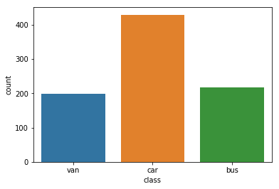

```python
print("Types of class:", vData['class'].unique())

print("\nValue Counts:\n",vData['class'].value_counts())

sns.countplot(vData['class'])
```

#### Deductions:

- The data is not distrubuted equally across the 3 types of classes. Appox Half of the data points are of type "car" and remaining from the types "bus" and "van" in appox. equal proportions.
- Meaning the model might tend to bias towards class "car". We can use sampling to reduce this bias.

### b. Independant attribute analysis

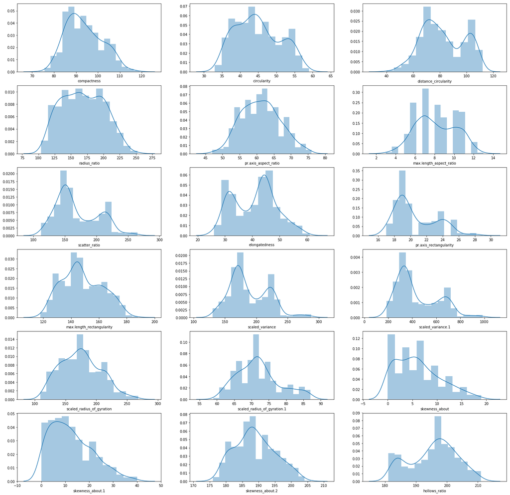

```python
# we will start with understanding the distrubtion of each attributes using distplot.

fig, axes = plt.subplots(nrows=6, ncols=3, figsize=(25, 25))
for i, column in enumerate(vData.columns[:-1]):
    sns.distplot(vData[column],ax=axes[i//3,i%3])
```

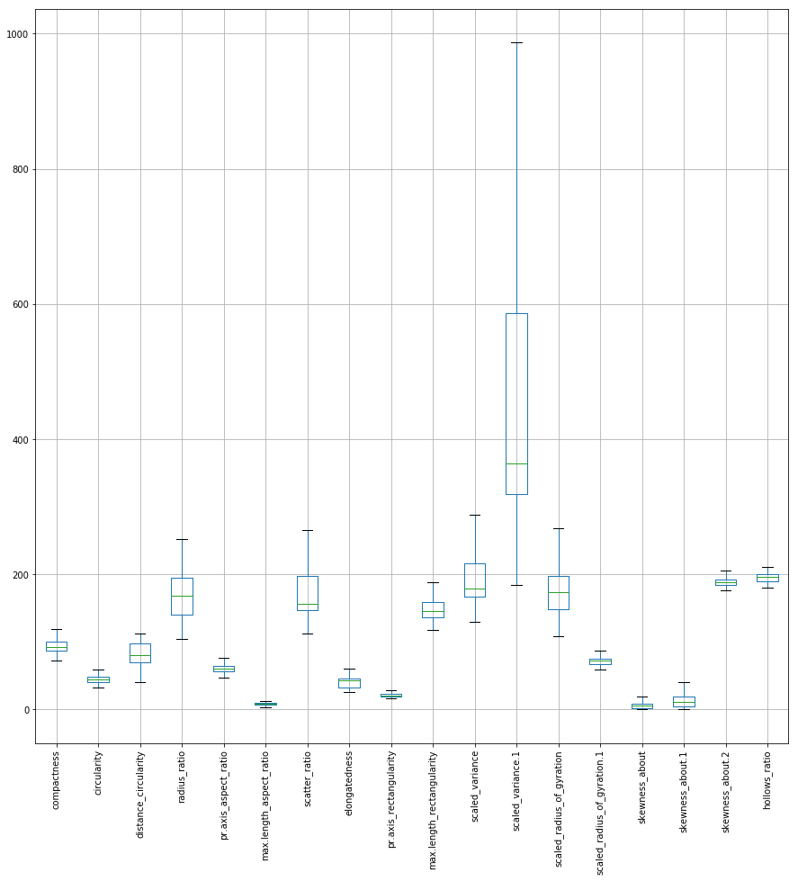

```python
plt.figure(figsize= (15,15))
vData.boxplot()
plt.xticks(rotation = 90)
```

### Deductions:

- Most of the attributes seems to be of bimodal/multimodal distributions (i.e.) we see more than one peaks.
- skewness_about.2 and pr.axis_aspect_ratio seems to be normally distrubuted.
- Many attributes seems to have long right tails. (ex: scaled_radius_of_gyration.1, scatter_ratio ..)
- As seen from boxplots, the scales of the attributes tend to vary, so it would be better to normalize the data.
- No presence of outliers as they are already dealt with in previous sections.

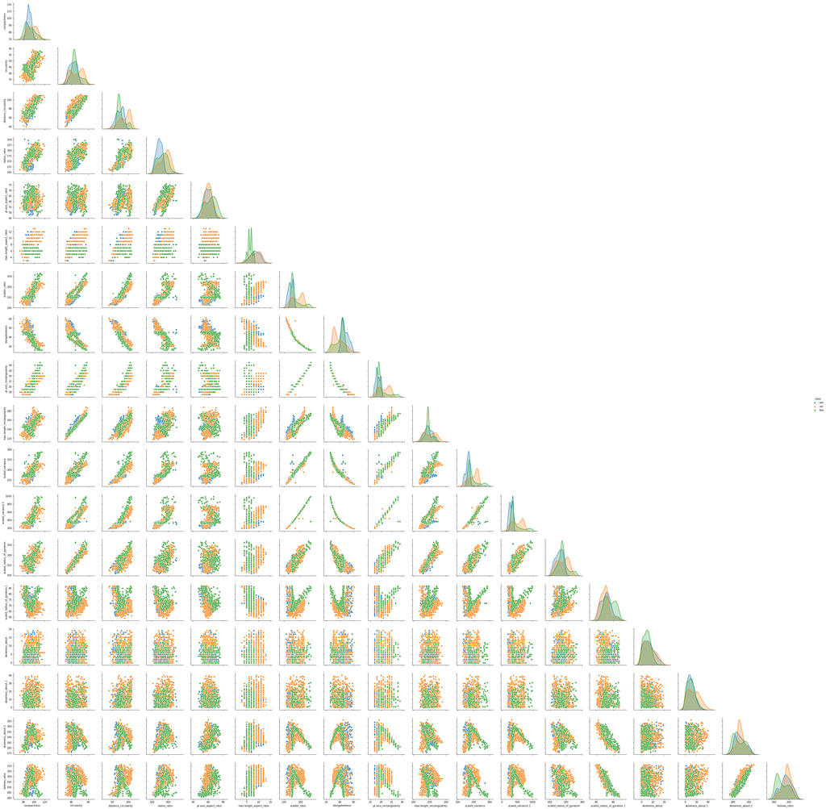

```python
# for the purpose of readability let us set visiblity only for lower triangle.
g = sns.pairplot(vData, hue='class')
for i, j in zip(*np.triu_indices_from(g.axes, 1)):
    g.axes[i, j].set_visible(False)
```

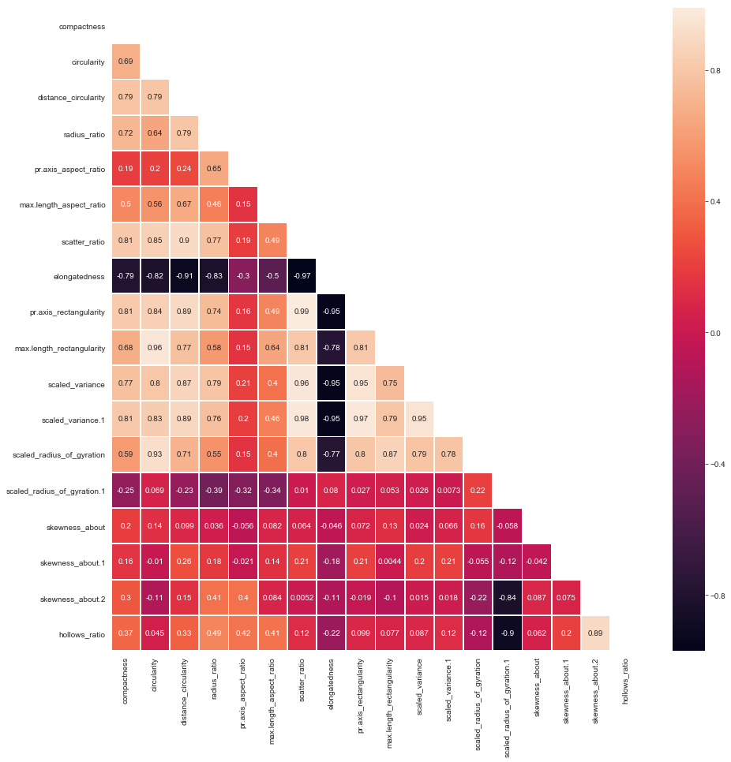

```python
# Heatmap
#Correlation Matrix
corr = vData.corr() # correlation matrix
lower_triangle = np.tril(corr, k = -1)  # select only the lower triangle of the correlation matrix
mask = lower_triangle == 0  # to mask the upper triangle in the following heatmap

plt.figure(figsize = (15,15))  # setting the figure size
sns.set_style(style = 'white')  # Setting it to white so that we do not see the grid lines
sns.heatmap(lower_triangle, annot= True, xticklabels = corr.index,yticklabels = corr.columns,linewidths= 1,mask = mask)   # Da Heatmap
plt.xticks(rotation = 90)   # Aesthetic purposes
plt.show()
```

## 3. Split the data into train and test (Suggestion: specify “random state” if you are using train_test_split from Sklearn)

### a. Seperating dependant/independant attributes

```python
#splitting dependant and independant attributes.

X = vData.drop(['class'],axis = 1)
y = vData[['class']]

print("shape of independant data: ", X.shape)
print("shape of dependant data: ", y.shape)
#y.head()
```

```
shape of independant data:  (846, 18)
shape of dependant data:  (846, 1)
```

```python
# encoding the class attribute.
y.replace({'car':0,'bus':1,'van':2},inplace=True)
#y.head()
```

### b. Scale the independant attributes

```python
# Scaling the attributes.

from scipy.stats import zscore
XScaled=X.apply(zscore)
XScaled.head()
```

|  | compactness | circularity | distance_circularity | radius_ratio | pr.axis_aspect_ratio | max.length_aspect_ratio | scatter_ratio | elongatedness | pr.axis_rectangularity | max.length_rectangularity | scaled_variance | scaled_variance.1 | scaled_radius_of_gyration | scaled_radius_of_gyration.1 | skewness_about | skewness_about.1 | skewness_about.2 | hollows_ratio |
| --- | --- | --- | --- | --- | --- | --- | --- | --- | --- | --- | --- | --- | --- | --- | --- | --- | --- | --- |
| 0 | 0.160580 | 0.517302 | 0.056545 | 0.300420 | 1.932830 | 0.912212 | -0.208038 | 0.136580 | -0.225160 | 0.758332 | -0.401938 | -0.338519 | 0.285618 | -0.317988 | -0.032895 | 0.386956 | -0.312193 | 0.183957 |
| 1 | -0.325470 | -0.624564 | 0.120112 | -0.851200 | -0.740875 | 0.427456 | -0.599893 | 0.520853 | -0.611739 | -0.344578 | -0.595419 | -0.619796 | -0.513719 | 0.006954 | 0.623522 | 0.161529 | 0.013088 | 0.452977 |
| 2 | 1.254193 | 0.843549 | 1.518571 | 1.265291 | 0.863348 | 0.912212 | 1.148382 | -1.144331 | 0.934576 | 0.689401 | 1.113664 | 1.131015 | 1.392391 | 0.169425 | 1.717551 | -0.402038 | -0.149552 | 0.049447 |
| 3 | -0.082445 | -0.624564 | -0.007021 | -0.290952 | 0.328607 | 0.427456 | -0.750606 | 0.648945 | -0.611739 | -0.344578 | -0.917888 | -0.740344 | -1.466773 | -1.455286 | -0.032895 | -0.289325 | 1.639494 | 1.529056 |
| 4 | -1.054545 | -0.135193 | -0.769817 | 1.140792 | -0.027887 | -0.057300 | -0.599893 | 0.520853 | -0.611739 | -0.275646 | 1.694107 | -0.648498 | 0.408593 | 0.006954 | 0.623522 | -0.176611 | -1.450677 | -1.699181 |

### C. Split data into train and test sets (Note: use random state)

```python
from sklearn.model_selection import train_test_split

X_train, X_test, y_train, y_test = train_test_split(XScaled, y, test_size=0.30, random_state=3)

print("Shape of X train : ",X_train.shape)
print("Shape of X_test  : ",X_test.shape)

#X_train.head()
```

```
Shape of X train :  (592, 18)
Shape of X_test  :  (254, 18)
```

## 4. Train a Support vector machine using the train set and get the accuracy on the test set

```python
# building an svm model
from sklearn import svm
from sklearn.metrics import confusion_matrix
from sklearn.metrics import classification_report

svm_model_1 = svm.SVC(gamma=0.025, C=3, kernel= 'linear')
svm_model_1.fit(X_train , y_train)
```

```
SVC(C=3, cache_size=200, class_weight=None, coef0=0.0,
  decision_function_shape='ovr', degree=3, gamma=0.025, kernel='linear',
  max_iter=-1, probability=False, random_state=None, shrinking=True,
  tol=0.001, verbose=False)
```

```python
# getting model accuracies.

y_predict_1 = svm_model_1.predict(X_test)

train_score_1 = svm_model_1.score(X_train,y_train)
test_score_1 = svm_model_1.score(X_test, y_test)

print("SVM_model_1 score for train set:", train_score_1*100)
print("SVM_model_1 score for test set:", test_score_1*100)

#Store the accuracy results for each model in a dataframe for final comparison
resultsDf = pd.DataFrame({'Method':['SVM (kernel: Linear)'], 'accuracy':test_score_1 })
resultsDf = resultsDf[['Method', 'accuracy']]


print("\n\nConfusion Matrix:\n   car bus van\n",confusion_matrix(y_test,y_predict_1))
target_names = ['car', 'bus', 'van']
print("\nClassification Report:\n", classification_report(y_test, y_predict_1, target_names=target_names))
#metrics.classification_report(y_test, y_predict_1, target_names=target_names)
resultsDf
```

```
SVM_model_1 score for train set: 95.6081081081081
SVM_model_1 score for test set: 94.48818897637796


Confusion Matrix:
   car bus van
 [[117   5   1]
 [  3  67   1]
 [  4   0  56]]

Classification Report:
               precision    recall  f1-score   support

         car       0.94      0.95      0.95       123
         bus       0.93      0.94      0.94        71
         van       0.97      0.93      0.95        60

   micro avg       0.94      0.94      0.94       254
   macro avg       0.95      0.94      0.94       254
weighted avg       0.95      0.94      0.94       254
```

|  | Method | accuracy |
| --- | --- | --- |
| 0 | SVM (kernel: Linear) | 0.944882 |

```python
# lets try out with a different kernel
# we will use the same gamma and C value throught. We will consider hyper parameter tuning later.

svm_model_2 = svm.SVC(gamma=0.025, C=3, kernel= 'rbf')
svm_model_2.fit(X_train , y_train)
```

```
SVC(C=3, cache_size=200, class_weight=None, coef0=0.0,
  decision_function_shape='ovr', degree=3, gamma=0.025, kernel='rbf',
  max_iter=-1, probability=False, random_state=None, shrinking=True,
  tol=0.001, verbose=False)
```

```python
y_predict_2 = svm_model_2.predict(X_test)

train_score_2 = svm_model_2.score(X_train,y_train)
test_score_2 = svm_model_2.score(X_test, y_test)

print("SVM_model_2 score for train set:", train_score_2*100)
print("SVM_model_2 score for test set:", test_score_2*100)

tempResultsDf = pd.DataFrame({'Method':['SVM (kernel: rbf)'], 'accuracy':test_score_2 })
resultsDf = pd.concat([resultsDf, tempResultsDf])
resultsDf = resultsDf[['Method', 'accuracy']]

print("\nConfusion Matrix:\n   car bus van\n",confusion_matrix(y_test,y_predict_2))
target_names = ['car', 'bus', 'van']
print("Classification report:\n", classification_report(y_test, y_predict_2, target_names=target_names))
#metrics.classification_report(y_test, y_predict_1, target_names=target_names)


resultsDf
```

```
SVM_model_2 score for train set: 97.2972972972973
SVM_model_2 score for test set: 96.06299212598425

Confusion Matrix:
   car bus van
 [[116   4   3]
 [  1  70   0]
 [  2   0  58]]
Classification report:
               precision    recall  f1-score   support

         car       0.97      0.94      0.96       123
         bus       0.95      0.99      0.97        71
         van       0.95      0.97      0.96        60

   micro avg       0.96      0.96      0.96       254
   macro avg       0.96      0.97      0.96       254
weighted avg       0.96      0.96      0.96       254
```

|  | Method | accuracy |
| --- | --- | --- |
| 0 | SVM (kernel: Linear) | 0.944882 |
| 0 | SVM (kernel: rbf) | 0.960630 |

### Lets try to tune the parameters and check for the best gamma and C value.

```python
#Grid search to tune model parameters for SVC
from sklearn.model_selection import GridSearchCV

c_range = range(5,15)
gamma_range = [0.001,0.025,0.05,0.04,0.03,0.1,0.5,1,10]
params = dict(C=c_range, gamma=gamma_range,kernel=['linear', 'rbf'])
model = GridSearchCV(svm.SVC(), param_grid=params, verbose=1)
model.fit(X_train, y_train)
print("Best Hyper Parameters:\n", model.best_params_)
```

```
Fitting 3 folds for each of 180 candidates, totalling 540 fits
```

```
[Parallel(n_jobs=1)]: Using backend SequentialBackend with 1 concurrent workers.
```

```
Best Hyper Parameters:
 {'C': 10, 'gamma': 0.05, 'kernel': 'rbf'}
```

```
[Parallel(n_jobs=1)]: Done 540 out of 540 | elapsed:    6.0s finished
```

#### We get the best paramters as : C = 10, and gamma=0.05 for rbf. Hence let us re-construct the model with these parameters.

```python
# Build svm model with C=10 and gamma=0.05 using rbf kernel

svm_model_3 = svm.SVC(gamma=0.05, C=10, kernel= 'rbf')
svm_model_3.fit(X_train , y_train)
```

```
SVC(C=10, cache_size=200, class_weight=None, coef0=0.0,
  decision_function_shape='ovr', degree=3, gamma=0.05, kernel='rbf',
  max_iter=-1, probability=False, random_state=None, shrinking=True,
  tol=0.001, verbose=False)
```

```python
y_predict_3 = svm_model_3.predict(X_test)

train_score_3 = svm_model_3.score(X_train,y_train)
test_score_3 = svm_model_3.score(X_test, y_test)

print("SVM_model_3 score for train set:", train_score_3*100)
print("SVM_model_3 score for test set:", test_score_3*100)

tempResultsDf = pd.DataFrame({'Method':['SVM - Tuned'], 'accuracy':test_score_3 })
resultsDf = pd.concat([resultsDf, tempResultsDf])
resultsDf = resultsDf[['Method', 'accuracy']]

print("\nConfusion Matrix:\n   car bus van\n",confusion_matrix(y_test,y_predict_3))
target_names = ['car', 'bus', 'van']
print("Classification report:\n", classification_report(y_test, y_predict_3, target_names=target_names))
#metrics.classification_report(y_test, y_predict_1, target_names=target_names)


resultsDf
```

```
SVM_model_3 score for train set: 99.32432432432432
SVM_model_3 score for test set: 96.8503937007874

Confusion Matrix:
   car bus van
 [[118   3   2]
 [  1  70   0]
 [  2   0  58]]
Classification report:
               precision    recall  f1-score   support

         car       0.98      0.96      0.97       123
         bus       0.96      0.99      0.97        71
         van       0.97      0.97      0.97        60

   micro avg       0.97      0.97      0.97       254
   macro avg       0.97      0.97      0.97       254
weighted avg       0.97      0.97      0.97       254
```

|  | Method | accuracy |
| --- | --- | --- |
| 0 | SVM (kernel: Linear) | 0.944882 |
| 0 | SVM (kernel: rbf) | 0.960630 |
| 0 | SVM - Tuned | 0.968504 |

#### Notice: We see a slight increase in model accuracy with parameter tuning.

### Deductions:

- For class type 'bus', the model has predicted 70/71 correctly.
- For class type 'van', the model has predicted 58/60 correctly.
- For class type 'car', the model has predicted 118/123 correctly.

## 5. Perform K-fold cross validation and get the cross validation score of the model

```python
from sklearn.model_selection import KFold
from sklearn.model_selection import cross_val_score


num_folds = 50
seed = 7

kfold = KFold(n_splits=num_folds, random_state=seed)
model = svm.SVC(gamma=0.05, C=10, kernel= 'rbf')
results = cross_val_score(model, XScaled, y, cv=kfold)
print(results)
print("Accuracy: %.3f%% (%.3f%%)" % (results.mean()*100.0, results.std()*100.0))

CVScores_Df = pd.DataFrame({'Method':['SVM - Tuned'], 'accuracy':results.mean()*100.0, 'std(+/-)':results.std()*100.0})
CVScores_Df = CVScores_Df[['Method', 'accuracy', 'std(+/-)']]
CVScores_Df
```

```
[0.94117647 0.88235294 0.94117647 1.         1.         0.94117647
 0.94117647 0.94117647 1.         1.         1.         1.
 1.         0.88235294 1.         1.         1.         1.
 1.         1.         0.94117647 1.         0.94117647 1.
 1.         1.         1.         1.         0.94117647 1.
 1.         1.         0.94117647 1.         1.         0.94117647
 1.         1.         0.94117647 0.94117647 0.94117647 1.
 1.         1.         1.         1.         0.9375     1.
 1.         0.9375    ]
Accuracy: 97.750% (3.322%)
```

|  | Method | accuracy | std(+/-) |
| --- | --- | --- | --- |
| 0 | SVM - Tuned | 97.75 | 3.321577 |

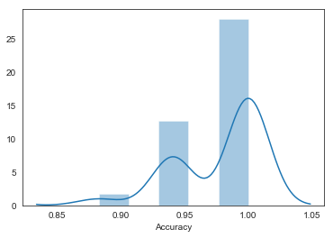

```
95.0 confidence interval 89.5% and 100.0%
```

```python
sns.distplot(results,kde=True,bins=5)
plt.xlabel("Accuracy")
plt.show()

# confidence intervals
alpha = 0.95                             # for 95% confidence

p = ((1.0-alpha)/2.0) * 100
lower = max(0.0, np.percentile(results, p))

p = (alpha+((1.0-alpha)/2.0)) * 100
upper = min(1.0, np.percentile(results, p))


print('%.1f confidence interval %.1f%% and %.1f%%' % (alpha*100, lower*100, upper*100))
```

#### As we see, the average model accuracy turns out to be 97.75%. And an accuracy between 90 to 100 can be acheived with 95% confidence.

## 6. Extract Principal Components that capture about 95% of the variance in the data

```python
# we have deduced in section 2 that some attributes have very low correlation.
# Hence we will not perform PCA for those attibutes

# So, we drop the columns 'pr.axis_aspect_ratio','max.length_aspect_ratio', 'skewness_about' and 'skewness_about.1'
# from PCA analysis.

XScaled_cp = XScaled.drop(['pr.axis_aspect_ratio','max.length_aspect_ratio', 'skewness_about', 'skewness_about.1'],axis=1)
XScaled_cp.shape
```

```
(846, 14)
```

```python
covMatrix = np.cov(XScaled_cp,rowvar=False)
print(covMatrix)
```

```
[[ 1.00118343  0.68623251  0.79084412  0.72284195  0.81319623 -0.78957587
   0.81459888  0.67694334  0.77148742  0.80904814  0.58584865 -0.24853609
   0.2988797   0.36598446]
 [ 0.68623251  1.00118343  0.79395399  0.63914881  0.84921058 -0.82287347
   0.84597164  0.96308094  0.80424197  0.83107165  0.92798524  0.06943233
  -0.1057698   0.04537164]
 [ 0.79084412  0.79395399  1.00118343  0.79523405  0.90547061 -0.91251368
   0.89418513  0.77558624  0.87108073  0.88632922  0.70678835 -0.23045959
   0.14573497  0.3324884 ]
 [ 0.72284195  0.63914881  0.79523405  1.00118343  0.77060345 -0.8266636
   0.74487406  0.58049352  0.78791632  0.76293107  0.55163932 -0.39108991
   0.40618509  0.49227551]
 [ 0.81319623  0.84921058  0.90547061  0.77060345  1.00118343 -0.97187169
   0.99054075  0.80931225  0.96165015  0.98240486  0.80021174  0.01003596
   0.00517279  0.11858838]
 [-0.78957587 -0.82287347 -0.91251368 -0.8266636  -0.97187169  1.00118343
  -0.9502004  -0.77643696 -0.9491023  -0.95125937 -0.76693543  0.07962014
  -0.11486327 -0.21697531]
 [ 0.81459888  0.84597164  0.89418513  0.74487406  0.99054075 -0.9502004
   1.00118343  0.81240688  0.94879798  0.97607102  0.79801083  0.02665869
  -0.01901199  0.09930879]
 [ 0.67694334  0.96308094  0.77558624  0.58049352  0.80931225 -0.77643696
   0.81240688  1.00118343  0.75133454  0.79199646  0.86744991  0.05319399
  -0.10437712  0.07686047]
 [ 0.77148742  0.80424197  0.87108073  0.78791632  0.96165015 -0.9491023
   0.94879798  0.75133454  1.00118343  0.94629611  0.78605894  0.02554037
   0.01539144  0.08734151]
 [ 0.80904814  0.83107165  0.88632922  0.76293107  0.98240486 -0.95125937
   0.97607102  0.79199646  0.94629611  1.00118343  0.78497867  0.00726815
   0.01799681  0.1206127 ]
 [ 0.58584865  0.92798524  0.70678835  0.55163932  0.80021174 -0.76693543
   0.79801083  0.86744991  0.78605894  0.78497867  1.00118343  0.21565325
  -0.22513165 -0.1182971 ]
 [-0.24853609  0.06943233 -0.23045959 -0.39108991  0.01003596  0.07962014
   0.02665869  0.05319399  0.02554037  0.00726815  0.21565325  1.00118343
  -0.83599129 -0.9044713 ]
 [ 0.2988797  -0.1057698   0.14573497  0.40618509  0.00517279 -0.11486327
  -0.01901199 -0.10437712  0.01539144  0.01799681 -0.22513165 -0.83599129
   1.00118343  0.89389629]
 [ 0.36598446  0.04537164  0.3324884   0.49227551  0.11858838 -0.21697531
   0.09930879  0.07686047  0.08734151  0.1206127  -0.1182971  -0.9044713
   0.89389629  1.00118343]]
```

```python
from sklearn.decomposition import PCA

pca = PCA(n_components=len(XScaled_cp.columns), whiten=False)
pca.fit(XScaled_cp)
```

```
PCA(copy=True, iterated_power='auto', n_components=14, random_state=None,
  svd_solver='auto', tol=0.0, whiten=False)
```

```python
print('Features Started with:', len(XScaled_cp.columns))
print()

print('Eigen Values: \n', pca.explained_variance_)
print()

print('Eigen Vector: \n', pca.components_)
print()

#print('Percentage variance explained: \n', pca.explained_variance_ratio_)
#print()

percent_variance = np.asarray([float(format(num, '.3f')) for num in pca.explained_variance_ratio_])
percent_variance = np.round(np.asarray(percent_variance) * 100, decimals =2)
print('Percentage variance explained:\n ', percent_variance)
```

```
Features Started with: 14

Eigen Values:
 [9.28300782e+00 3.10339866e+00 5.75928274e-01 3.00512636e-01
 2.30698417e-01 1.48670701e-01 1.14636748e-01 7.74722811e-02
 5.67762642e-02 4.08852681e-02 3.51559833e-02 2.28683367e-02
 2.05182103e-02 6.03844758e-03]

Eigen Vector:
 [[ 0.27856343  0.29625477  0.30667077  0.27117392  0.32111904 -0.31796911
   0.31828912  0.28488278  0.31186052  0.31691556  0.27514479 -0.02951521
   0.02981277  0.07216822]
 [ 0.12596196 -0.11823446  0.0709841   0.20824018 -0.04997205 -0.01066403
  -0.06191266 -0.1078662  -0.05167934 -0.04527503 -0.20025503 -0.53414506
   0.53598676  0.53502976]
 [ 0.11317235 -0.46356558  0.02934805  0.17308433  0.19126941 -0.18716856
   0.18035696 -0.54246874  0.27461881  0.20893355 -0.38766199  0.19550468
   0.00779506 -0.1882261 ]
 [-0.78707333  0.02919004  0.08588139  0.50407925 -0.02484964 -0.1535799
  -0.09437612 -0.12444445  0.13494758 -0.0531928   0.16840722 -0.10482485
  -0.09577652  0.00563364]
 [ 0.15029788  0.10105985 -0.55394051  0.31548726 -0.08452252  0.00511659
  -0.11997092 -0.07585219  0.09831272 -0.0480311   0.32566343  0.37228263
   0.51352075 -0.11476661]
 [ 0.44573093  0.03159462  0.03824563  0.62080119 -0.17304282  0.24199258
  -0.15490143 -0.021651   -0.08735333 -0.19944772 -0.05221782 -0.19097474
  -0.42049532 -0.19255404]
 [ 0.10244944 -0.08478657  0.05292941 -0.27485696 -0.01209115  0.08044944
  -0.00342237 -0.44925454  0.17143719 -0.00491688  0.60647069 -0.47396753
   0.00780065 -0.27125665]
 [-0.12858998  0.11580345 -0.63536141  0.01527965  0.16758233  0.06760255
   0.24769795  0.17519833  0.01961416  0.30979165 -0.24695172 -0.47313245
  -0.09499865 -0.22630537]
 [-0.01595379  0.09515086  0.18220132 -0.10524823 -0.11921769 -0.08304498
  -0.22536986  0.2794396   0.51896493 -0.32175618 -0.31228939 -0.14784588
   0.28757379 -0.47063415]
 [ 0.00413234 -0.21884814 -0.21391144 -0.06249059 -0.04778091  0.34063692
   0.06200375  0.12839548  0.6667181  -0.1308471   0.08598863  0.07090787
  -0.27006533  0.46560455]
 [ 0.13809189  0.04745459 -0.30922065 -0.10366651  0.11482306 -0.71563915
  -0.07929677 -0.08532535 -0.00772547 -0.47410971  0.00476314 -0.08928971
  -0.26796588  0.16965159]
 [-0.07945271  0.10088989  0.05664659  0.0604577   0.20095905  0.23934778
   0.69713744 -0.08646842 -0.10642719 -0.58895821 -0.01851401  0.03741449
   0.14138324 -0.07459806]
 [-0.00680638 -0.7606608  -0.00859213  0.09289967 -0.00177909 -0.13983044
   0.10751686  0.4984077  -0.17731208 -0.06746474  0.24951604 -0.06906435
   0.06908536 -0.15914403]
 [-0.01570897 -0.05209932  0.00483836  0.0180562   0.84958698  0.24212593
  -0.44179792  0.0310191  -0.0520661  -0.12688298  0.02080393  0.00369239
   0.02807714 -0.00859764]]

Percentage variance explained:
  [66.2 22.1  4.1  2.1  1.6  1.1  0.8  0.6  0.4  0.3  0.3  0.2  0.1  0. ]
```

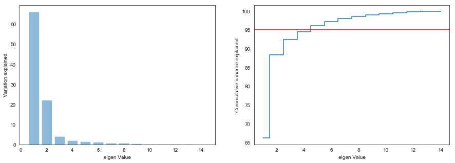

```python
plt.figure(figsize=(15,5))

plt.subplot(1,2,1)
plt.bar(list(range(1,15)),percent_variance,alpha=0.5, align='center')
plt.ylabel('Variation explained')
plt.xlabel('eigen Value')

plt.subplot(1,2,2)
plt.step(list(range(1,15)),np.cumsum(percent_variance), where='mid')
plt.axhline(y=95, color='r', linestyle='-')
plt.ylabel('Cummulative variance explained')
plt.xlabel('eigen Value')
plt.show()
```

#### As we see from the above graph, 95% of the variation in data can be explained using 5 features.

#### Reducing the dimentionality.

```python
# 5 features explain 95 % of the variance
pca_rd = PCA(n_components=5)
pca_rd.fit(XScaled_cp)
```

```
PCA(copy=True, iterated_power='auto', n_components=5, random_state=None,
  svd_solver='auto', tol=0.0, whiten=False)
```

```python
print(pca_rd.components_)
print()

print(pca_rd.explained_variance_ratio_)
print()
```

```
[[ 0.27856343  0.29625477  0.30667077  0.27117392  0.32111904 -0.31796911
   0.31828912  0.28488278  0.31186052  0.31691556  0.27514479 -0.02951521
   0.02981277  0.07216822]
 [ 0.12596196 -0.11823446  0.0709841   0.20824018 -0.04997205 -0.01066403
  -0.06191266 -0.1078662  -0.05167934 -0.04527503 -0.20025503 -0.53414506
   0.53598676  0.53502976]
 [ 0.11317235 -0.46356558  0.02934805  0.17308433  0.19126941 -0.18716856
   0.18035696 -0.54246874  0.27461881  0.20893355 -0.38766199  0.19550468
   0.00779506 -0.1882261 ]
 [-0.78707333  0.02919004  0.08588139  0.50407925 -0.02484964 -0.1535799
  -0.09437612 -0.12444445  0.13494758 -0.0531928   0.16840722 -0.10482485
  -0.09577652  0.00563364]
 [ 0.15029788  0.10105985 -0.55394051  0.31548726 -0.08452252  0.00511659
  -0.11997092 -0.07585219  0.09831272 -0.0480311   0.32566343  0.37228263
   0.51352075 -0.11476661]]

[0.66228821 0.22140931 0.04108911 0.02143982 0.01645898]
```

```python
#print(XScaled_cp.columns)
XScaled_cp_pca = pd.DataFrame(pca_rd.transform(XScaled_cp))

print("shape after dimenationality reduction:", XScaled_cp_pca.shape)

XScaled_cp_pca.head()
```

```
shape after dimenationality reduction: (846, 5)
```

|  | 0 | 1 | 2 | 3 | 4 |
| --- | --- | --- | --- | --- | --- |
| 0 | 0.190238 | 0.046564 | -1.076366 | 0.032213 | -0.102409 |
| 1 | -1.611391 | 0.370950 | -0.204410 | -0.278617 | -0.532960 |
| 2 | 3.717549 | -0.279679 | 0.267894 | 0.100377 | 0.053618 |
| 3 | -1.751575 | 2.956860 | -0.356491 | -0.408367 | -0.404824 |
| 4 | -0.622878 | -1.672286 | 0.426382 | 1.822505 | 0.545258 |

#### Now let us combine the 4 features left out of the PCA with the reduced features and prepare the data for modelling.

```python
X_non_pca = XScaled[['pr.axis_aspect_ratio','max.length_aspect_ratio', 'skewness_about', 'skewness_about.1']]

XScaled_pca = pd.merge(XScaled_cp_pca, X_non_pca, right_index=True, left_index=True)

print("Final shape of the data: ", XScaled_pca.shape)

XScaled_pca.head()
```

```
Final shape of the data:  (846, 9)
```

|  | 0 | 1 | 2 | 3 | 4 | pr.axis_aspect_ratio | max.length_aspect_ratio | skewness_about | skewness_about.1 |
| --- | --- | --- | --- | --- | --- | --- | --- | --- | --- |
| 0 | 0.190238 | 0.046564 | -1.076366 | 0.032213 | -0.102409 | 1.932830 | 0.912212 | -0.032895 | 0.386956 |
| 1 | -1.611391 | 0.370950 | -0.204410 | -0.278617 | -0.532960 | -0.740875 | 0.427456 | 0.623522 | 0.161529 |
| 2 | 3.717549 | -0.279679 | 0.267894 | 0.100377 | 0.053618 | 0.863348 | 0.912212 | 1.717551 | -0.402038 |
| 3 | -1.751575 | 2.956860 | -0.356491 | -0.408367 | -0.404824 | 0.328607 | 0.427456 | -0.032895 | -0.289325 |
| 4 | -0.622878 | -1.672286 | 0.426382 | 1.822505 | 0.545258 | -0.027887 | -0.057300 | 0.623522 | -0.176611 |

#### After PCA, we reduced the data set to contain 9 features.

## 7. Repeat steps 3,4 and 5 but this time, use Principal Components instead of the original data

```python
# for data split we will use the same random state as above, to ensure the accuracy can be compared on same rows.
# so we give the same random state.

print("shape after pca:", XScaled_pca.shape)
X_pca_train, X_pca_test, y_pca_train, y_pca_test = train_test_split(XScaled_pca, y, test_size=0.30, random_state=3)

print("Shape of X train : ",X_pca_train.shape)
print("Shape of X_test  : ",X_pca_test.shape)
print("Shape of y train : ",y_pca_train.shape)
print("Shape of y_test  : ",y_pca_test.shape)
```

```
shape after pca: (846, 9)
Shape of X train :  (592, 9)
Shape of X_test  :  (254, 9)
Shape of y train :  (592, 1)
Shape of y_test  :  (254, 1)
```

#### We start with the base model we created in Step-3

```python
svm_model_4 = svm.SVC(gamma=0.025, C=3, kernel= 'rbf')
svm_model_4.fit(X_pca_train , y_pca_train)

y_predict_4 = svm_model_4.predict(X_pca_test)

train_score_4 = svm_model_4.score(X_pca_train,y_pca_train)
test_score_4 = svm_model_4.score(X_pca_test, y_pca_test)

print("SVM_model_4 score for train set:", train_score_4*100)
print("SVM_model_4 score for test set:", test_score_4*100)

#Store the accuracy results for each model in a dataframe for final comparison
tempResultsDf = pd.DataFrame({'Method':['SVM with PCA (kernel: rbf)'], 'accuracy':test_score_4 })
resultsDf = pd.concat([resultsDf, tempResultsDf])
resultsDf = resultsDf[['Method', 'accuracy']]


print("\n\nConfusion Matrix:\n   car bus van\n",confusion_matrix(y_pca_test,y_predict_4))
target_names = ['car', 'bus', 'van']
print("\nClassification Report:\n", classification_report(y_pca_test, y_predict_4, target_names=target_names))

resultsDf
```

```
SVM_model_4 score for train set: 94.5945945945946
SVM_model_4 score for test set: 94.09448818897637


Confusion Matrix:
   car bus van
 [[113   5   5]
 [  0  71   0]
 [  3   2  55]]

Classification Report:
               precision    recall  f1-score   support

         car       0.97      0.92      0.95       123
         bus       0.91      1.00      0.95        71
         van       0.92      0.92      0.92        60

   micro avg       0.94      0.94      0.94       254
   macro avg       0.93      0.95      0.94       254
weighted avg       0.94      0.94      0.94       254
```

|  | Method | accuracy |
| --- | --- | --- |
| 0 | SVM (kernel: Linear) | 0.944882 |
| 0 | SVM (kernel: rbf) | 0.960630 |
| 0 | SVM - Tuned | 0.968504 |
| 0 | SVM with PCA (kernel: rbf) | 0.940945 |

#### Now, lets create a model with tuned parameters.

```python
# with tuned parameters
svm_model_5 = svm.SVC(gamma=0.05, C=10, kernel= 'rbf')
svm_model_5.fit(X_pca_train , y_pca_train)
```

```
SVC(C=10, cache_size=200, class_weight=None, coef0=0.0,
  decision_function_shape='ovr', degree=3, gamma=0.05, kernel='rbf',
  max_iter=-1, probability=False, random_state=None, shrinking=True,
  tol=0.001, verbose=False)
```

```python
y_predict_5 = svm_model_5.predict(X_pca_test)

train_score_5 = svm_model_5.score(X_pca_train,y_pca_train)
test_score_5 = svm_model_5.score(X_pca_test, y_pca_test)

print("SVM_model_5 score for train set:", train_score_5*100)
print("SVM_model_5 score for test set:", test_score_5*100)

#Store the accuracy results for each model in a dataframe for final comparison
tempResultsDf = pd.DataFrame({'Method':['SVM with PCA -Tuned'], 'accuracy':test_score_5 })
resultsDf = pd.concat([resultsDf, tempResultsDf])
resultsDf = resultsDf[['Method', 'accuracy']]


print("\n\nConfusion Matrix:\n   car bus van\n",confusion_matrix(y_pca_test,y_predict_5))
target_names = ['car', 'bus', 'van']
print("\nClassification Report:\n", classification_report(y_pca_test, y_predict_5, target_names=target_names))

resultsDf
```

```
SVM_model_5 score for train set: 97.97297297297297
SVM_model_5 score for test set: 94.88188976377953


Confusion Matrix:
   car bus van
 [[116   3   4]
 [  0  71   0]
 [  5   1  54]]

Classification Report:
               precision    recall  f1-score   support

         car       0.96      0.94      0.95       123
         bus       0.95      1.00      0.97        71
         van       0.93      0.90      0.92        60

   micro avg       0.95      0.95      0.95       254
   macro avg       0.95      0.95      0.95       254
weighted avg       0.95      0.95      0.95       254
```

|  | Method | accuracy |
| --- | --- | --- |
| 0 | SVM (kernel: Linear) | 0.944882 |
| 0 | SVM (kernel: rbf) | 0.960630 |
| 0 | SVM - Tuned | 0.968504 |
| 0 | SVM with PCA (kernel: rbf) | 0.940945 |
| 0 | SVM with PCA -Tuned | 0.948819 |

#### Now lets perform K-fold cross validation and check for 95% confidence intervals

```python
num_folds = 50
seed = 7

kfold = KFold(n_splits=num_folds, random_state=seed)
model = svm.SVC(gamma=0.05, C=10, kernel= 'rbf')
results = cross_val_score(model, XScaled_pca, y, cv=kfold)
print(results)
print("Accuracy: %.3f%% (%.3f%%)" % (results.mean()*100.0, results.std()*100.0))

tempCVScores_Df = pd.DataFrame({'Method':['SVM with PCA -tuned'], 'accuracy':results.mean()*100.0, 'std(+/-)':results.std()*100.0})
CVScores_Df = pd.concat([CVScores_Df, tempCVScores_Df])
CVScores_Df = CVScores_Df[['Method', 'accuracy', 'std(+/-)']]
CVScores_Df
```

```
[1.         0.82352941 0.94117647 0.94117647 0.88235294 0.94117647
 0.94117647 0.88235294 1.         1.         0.94117647 1.
 0.82352941 0.88235294 1.         0.94117647 0.94117647 0.88235294
 0.94117647 1.         0.94117647 0.94117647 0.82352941 1.
 1.         1.         0.94117647 1.         0.94117647 1.
 0.82352941 0.94117647 0.94117647 1.         0.94117647 0.82352941
 0.88235294 1.         0.94117647 0.88235294 0.88235294 0.94117647
 1.         1.         1.         1.         0.9375     1.
 1.         0.9375    ]
Accuracy: 94.338% (5.638%)
```

|  | Method | accuracy | std(+/-) |
| --- | --- | --- | --- |
| 0 | SVM - Tuned | 97.750000 | 3.321577 |
| 0 | SVM with PCA -tuned | 94.338235 | 5.638320 |

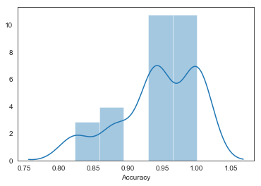

```
95.0 confidence interval 82.4% and 100.0%
```

```python
sns.distplot(results,kde=True,bins=5)
plt.xlabel("Accuracy")
plt.show()

# confidence intervals
alpha = 0.95                             # for 95% confidence

p = ((1.0-alpha)/2.0) * 100
lower = max(0.0, np.percentile(results, p))

p = (alpha+((1.0-alpha)/2.0)) * 100
upper = min(1.0, np.percentile(results, p))


print('%.1f confidence interval %.1f%% and %.1f%%' % (alpha*100, lower*100, upper*100))
```

#### cross validation score for model after reducing dimentionality using PCA and tuning parameters is 94.33%

## 8. Compare the accuracy scores and cross validation scores

```python
# accuracy scores:

resultsDf
```

|  | Method | accuracy |
| --- | --- | --- |
| 0 | SVM (kernel: Linear) | 0.944882 |
| 0 | SVM (kernel: rbf) | 0.960630 |
| 0 | SVM - Tuned | 0.968504 |
| 0 | SVM with PCA (kernel: rbf) | 0.940945 |
| 0 | SVM with PCA -Tuned | 0.948819 |

#### Deductions:

1. SVM on raw data perform better for Kernel = rbf with an slight advantage of appox ~2% in accuracy.
2. When tuned for hyper paramters, C=10 and gamma=0.05 acheived an accuracy of 96.85%, a slight increase on model without tuning.
3. Accuracy scores with PCA seems to have dropped slightly by ~2%. But it is to be noted that this has been achived with 50% reduction in dimentions.(PCA has reduced the dimentionality from 18 to 9.)

```python
# comparing cross validation scores of raw data and with PCA

CVScores_Df
```

|  | Method | accuracy | std(+/-) |
| --- | --- | --- | --- |
| 0 | SVM - Tuned | 97.750000 | 3.321577 |
| 0 | SVM with PCA -tuned | 94.338235 | 5.638320 |

#### Deductions:

- The accuracy of individual models SVM- Tuned(96.85%) falls well within range of the cross validation score of 97.75% with a standard deviation of (+/- 3.32).
- Similarliy, for Model with PCA (94.88%) is appox equal to cross validation score of 94.33% with standard deviation of (+/- 5.6).
- Hence we can conlcude both our models on raw data and with PCA perform well without any overfitting/underfitting.

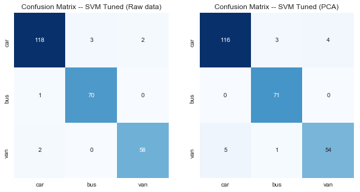

```python
## Confusion matrix

plt.figure(figsize=(10,5))
class_label = ["car", "bus", "van"]
plt.xlabel("Predicted Class")
plt.ylabel("True Class")


plt.subplot(1,2,1)
svm_cm = confusion_matrix(y_test, y_predict_3)
df_cm = pd.DataFrame(svm_cm, index = class_label, columns = class_label)
sns.heatmap(df_cm, annot = True, fmt='d', cbar= False, cmap="Blues")
plt.title("Confusion Matrix -- SVM Tuned (Raw data)")

plt.subplot(1,2,2)
pca_cm = confusion_matrix(y_pca_test,y_predict_5)
df_cm1 = pd.DataFrame(pca_cm, index = class_label, columns = class_label)
sns.heatmap(df_cm1, annot = True,fmt = "d",cbar= False, cmap="Blues")
plt.title("Confusion Matrix -- SVM Tuned (PCA)")

plt.show()
```

```python
target_names = ['car', 'bus', 'van']
print("\nClassification Report for SVM -Tuned (RAW data):\n", classification_report(y_test, y_predict_3, target_names=target_names))
print()
print()
print("\nClassification Report for SVM -Tuned (PCA):\n", classification_report(y_pca_test, y_predict_5, target_names=target_names))
```

```
Classification Report for SVM -Tuned (RAW data):
               precision    recall  f1-score   support

         car       0.98      0.96      0.97       123
         bus       0.96      0.99      0.97        71
         van       0.97      0.97      0.97        60

   micro avg       0.97      0.97      0.97       254
   macro avg       0.97      0.97      0.97       254
weighted avg       0.97      0.97      0.97       254




Classification Report for SVM -Tuned (PCA):
               precision    recall  f1-score   support

         car       0.96      0.94      0.95       123
         bus       0.95      1.00      0.97        71
         van       0.93      0.90      0.92        60

   micro avg       0.95      0.95      0.95       254
   macro avg       0.95      0.95      0.95       254
weighted avg       0.95      0.95      0.95       254
```

#### Deductions:

1. The SVM with PCA predicted correclty for all class = 'bus' as evident from recall = 1.00
2. For class = 'car', the incorrect prediction have increased by 2. The precision and recall reduced by 2% when tuned with PCA
3. For class = 'van', the no.of incorrect predictions have increased most among the three class types. The precision and recall fell down by 4% & 7% respectively. However note: PCA has reduced dimentionality by 50%.  
   Since, accuracy has not dropped substancially, we can consider SVM tuned using PCA to be the best model for this case.

#### Model Summary:

**Model** : SVM,  
**Parameters** : C = 10, gamma = 0.05  
**No.of Features used** : 9  
**Model Accuracy** : 94.88%